# Good Coding Practices

Andrew Do

July 12, 2016

## Short Exercises

Rewrite the following according to our class style guide:

1.

```r
x < - c( NA,1,-2,3,-4,5 )
  y<-3
  y<-x * - 1
  y[ y>0 ]
```

```r
# <Your fix here>
x <- c(NA, 1, -2, 3, -4, 5)
y <- 3
y <- x * -1
y[y > 0]
```

```
## [1] NA  2  4
```

```r
mean <- function(x) {
sum (x)/length( x )
}
```

```r
# <Your fix here>
mean <- function(x) {
  # Computes the mean of a vector
  #
  # Args:
  #   x: Vector whose mean is to be calculated
  sum(x) / length(x)
}
```

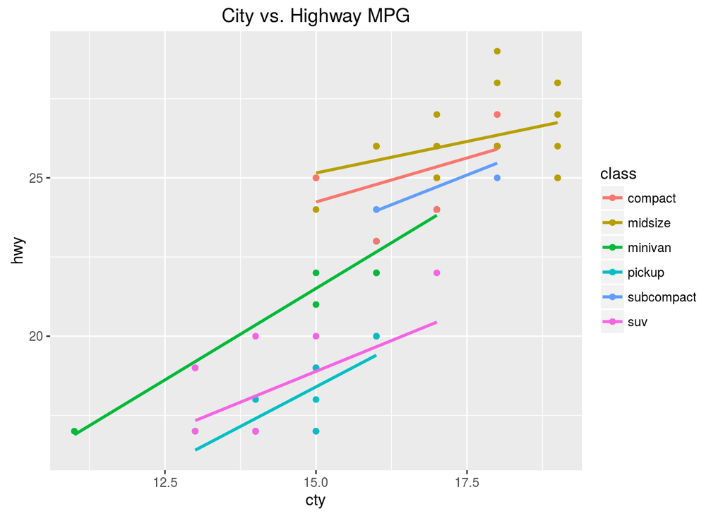

```r
library( ggplot2 )
second_version_of_mpg <- mpg[ mpg$cyl == 6,]
second_version_of_mpg$class <- as.character(second_version_of_mpg$class)
ggplot(data=second_version_of_mpg,aes(cty,hwy,color=class))+geom_point()+geom_smooth( method = "lm", se=FALSE ) + labs (title="City vs. Highway MPG" )
```

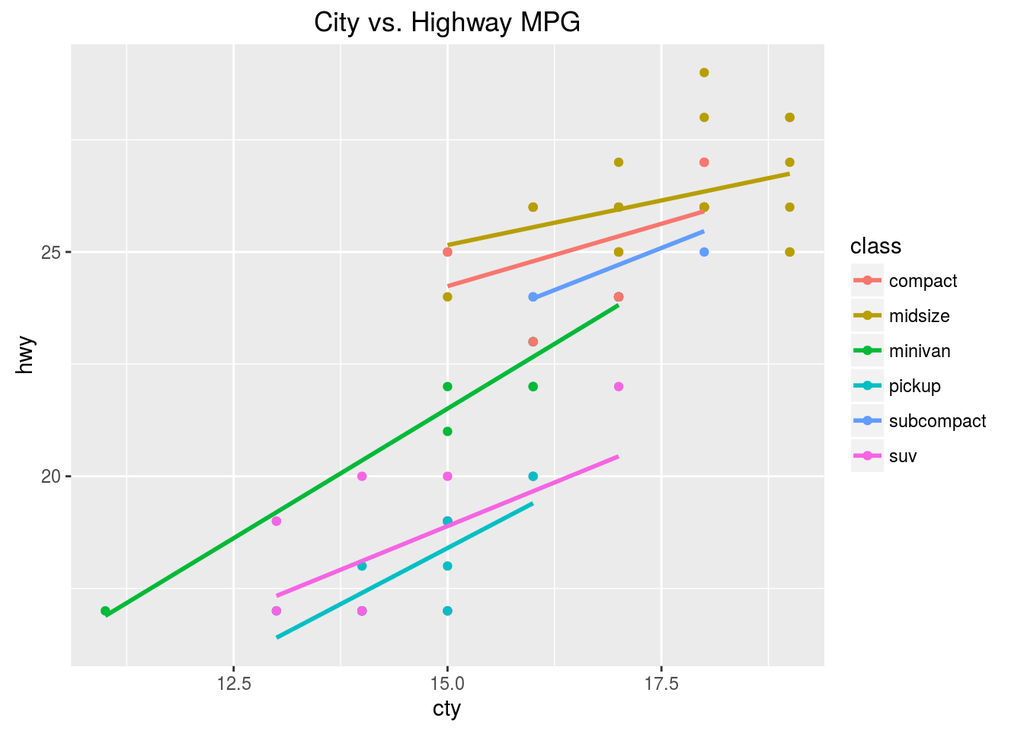

```r
# <Your fix here>
library(ggplot2)
second_version_of_mpg <- mpg[mpg$cyl == 6, ]
second_version_of_mpg$class <- as.character(second_version_of_mpg$class)
ggplot(data = second_version_of_mpg, aes(cty, hwy, color = class)) +
  geom_point() +
  geom_smooth(method = "lm", se = FALSE) +
  labs(title = "City vs. Highway MPG")
```

## Longer Exercises

Fix the following code with the following goals:

- Readability - an untrained person should be able to guess what’s going on
  - Use meaningful names
  - Use whitespace to make the code flow
  - Provide documentation
  - Use functions from the packages we’ve covered (they’re designed to be readable!)
- Compactness - do not be more verbose than you have to be
  - Think of ways to vectorize the function
  - Avoid copy-paste
  - Use the `lapply` family
  - Modularize your code (small functions instead of massive ones)
- Usable as intended
  - If necessary, include error messages
  - Don’t force the user to rely on implicit coercion
  - Output the intentional data type

### Exercise 1

Infer what the function `d` is doing and rewrite it according to our class style guide. Include documentation so that future users won’t have to decipher the code.

```r
d <- function(f, x, y, s) {
  stuff<-seq(x,y,by=s)
  stuff2<-c()
  for(i in 1:length(stuff)){thing<-f(stuff[i]); stuff2[i]<-thing}
  m<-max(stuff2)
  mm<-stuff[stuff2==m]
  mm<-min(mm)
  return(list(m,mm))
}

# Example usage
g <- function(x) -(x ^ 2)
d(g, -1, 1, .1)
```

```
## [[1]]
## [1] 0
##
## [[2]]
## [1] 0
```

```r
# <Your fix here>
MaxAndMin <- function(f, x, y, s) {
  # Returns a list of the max of an arbitrary function applied to a vector and the
  # minimum of the numbers that produce that max in the original vector before the
  # function is applied.
  #
  # Args:
  #   f: function
  #   x: start of sequence
  #   y: end of sequence
  #   s: sequence increment
  # Return:
  #   list of max of functionized vector and minimum of numbers that produce max
  #   from original vector
  v <- seq(x, y, by = s)
  v2 <- sapply(v, f)
  max <- max(v2)
  max_index <- v[v2 == max]
  min <- min(max_index)
  return(list(max, min))
}

# Example Usage
g <- function(x) {
  x^2
}
MaxAndMin(g, -1, 1, 0.1)
```

```
## [[1]]
## [1] 1
##
## [[2]]
## [1] -1
```

### Exercise 2

Figure out what the `ss` function is doing, rewrite it so it uses more expressive functions according to our style guide. Provide documentation.

```r
ss <- function(x)
{x<-x[!is.na(x)]
a<-x[1];for(i in 2:length(x)) a[i]<-(a[i-1]+x[i])
a<-a/(1:length(x))
foo<-x
cc<-0
for(i in 1:length(foo)){x<-foo[1:i]
c<-sort(x);
if(length(x)%%2==0){cc[i]<-(c[floor((length(c)+1)/2)] + c[ceiling((length(c)+1)/2)])/2} else{ cc[i]<-c[(length(c)+1)/2]}}
return(list(a,cc))
}

# Example usage
ss(c(5,10,15,20,5,10,15,20))
```

```
## [[1]]
## [1]  5.00000  7.50000 10.00000 12.50000 11.00000 10.83333 11.42857 12.50000
##
## [[2]]
## [1]  5.0  7.5 10.0 12.5 10.0 10.0 10.0 12.5
```

```r
ss(1:10)
```

```
## [[1]]
##  [1] 1.0 1.5 2.0 2.5 3.0 3.5 4.0 4.5 5.0 5.5
##
## [[2]]
##  [1] 1.0 1.5 2.0 2.5 3.0 3.5 4.0 4.5 5.0 5.5
```

```r
ss(c(1,2,6,2,4,5))
```

```
## [[1]]
## [1] 1.000000 1.500000 3.000000 2.750000 3.000000 3.333333
##
## [[2]]
## [1] 1.0 1.5 2.0 2.0 2.0 3.0
```

```r
# <Your fix here>
ss <- function(x) {
  # Returns the cumulative max and median of a vector
  #
  # Args:
  #   x: vector
  # Return:
  #   list of cumulative mean and median
  x <- x[!is.na(x)]
  lst <- x[1]
  for (i in 2:length(x)) {
    lst[i] <- lst[i - 1] + x[i]
  }
  cummean <- lst / (1:length(x))
  lst <- x
  cummedian <- 0
  for(i in 1:length(lst)) {
    x <- lst[1:i]
    c <- sort(x)
    if(length(x) %% 2 == 0) {
      cummedian[i] <- (c[floor((length(c) + 1) / 2)] +
                         c[ceiling((length(c) + 1) / 2)]) / 2
    } else {
      cummedian[i] <- c[c(length(c) + 1) / 2]
    }
  }
  return(list(cummean, cummedian))
}

ss(c(5, 10, 15, 20, 5, 10, 15, 20))
```

```
## [[1]]
## [1]  5.00000  7.50000 10.00000 12.50000 11.00000 10.83333 11.42857 12.50000
##
## [[2]]
## [1]  5.0  7.5 10.0 12.5 10.0 10.0 10.0 12.5
```

```r
ss(1:10)
```

```
## [[1]]
##  [1] 1.0 1.5 2.0 2.5 3.0 3.5 4.0 4.5 5.0 5.5
##
## [[2]]
##  [1] 1.0 1.5 2.0 2.5 3.0 3.5 4.0 4.5 5.0 5.5
```

```r
ss(c(1, 2, 6, 2, 4, 5))
```

```
## [[1]]
## [1] 1.000000 1.500000 3.000000 2.750000 3.000000 3.333333
##
## [[2]]
## [1] 1.0 1.5 2.0 2.0 2.0 3.0
```

### Exercise 3

Rewrite the following script in a more compact form using packages we’ve covered in this class. It shouldn’t take more than 7 function calls—3 if you took the time to read the `dplyr` vignette!

```r
d<-iris
dd<-unique(d[,5])
d1<-d[which(d[,5]==dd[1]),]
d2<-d[which(d[,5]==dd[2]),]
d3<-d[which(d[,5]==dd[3]),]
d1[,1] <- mean(d1[,1])
d1[,2] <- mean(d1[,2])
d1[,3] <- mean(d1[,3])
d1[,4] <- mean(d1[,4])
d2[,1] <- mean(d2[,1])
d2[,2] <- mean(d2[,2])
d2[,3] <- mean(d2[,3])
d2[,4] <- mean(d2[,4])
d3[,1] <- mean(d3[,1])
d3[,2] <- mean(d3[,2])
d3[,3] <- mean(d3[,3])
d3[,4] <- mean(d3[,4])
ddd<-rbind(d1[1,],d2[1,],d3[1,])
rownames(ddd) <- NULL
```

```r
# <Your fix here>
library(dplyr)
d <- iris %>%
  group_by(Species) %>%
  summarise(Sepal.Length = mean(Sepal.Length),
            Sepal.Width = mean(Sepal.Width),
            Petal.Length = mean(Petal.Length),
            Petal.Width = mean(Petal.Width)) %>%
  select(Sepal.Length, Sepal.Width, Petal.Length, Petal.Width, Species)
```

## Remote Computing Practice

Upload the `.rmd` file to `Documents/lab19/` on your server account and knit it using the command line. Submit the `.html` file produced by knitting on the server. Assuming you’re in the folder with the markdown file on the server, the command is:

```bash
Rscript -e "rmarkdown::render('lab19.Rmd')"
```